# Final_Report

Group_7

2020/11/30

## Overview

In this project, we are going to use 5 different ways to estimate propensity scores and two algorithms to estimate ATE. They are:

- Logistic Regression + Full Matching
- L1 Logistic Reg + Full Matching
- L2 Logistic Reg + Full Matching
- CART + Full Matching
- Boosting Stumps + Full Matching
- Logistic Regression + Weighted Regression

#### Step 0.1 Load Required Packages

```r
packages.used <- c("grDevices","glmnet","rpart","gbm","MatchIt","readr","dplyr","reshape2","tidyverse","smotefamily","knitr")
# check packages that need to be installed.
#packages.needed <- setdiff(packages.used,
#                           intersect(installed.packages()[,1],
#                                     packages.used))
# install additional packages
#if(length(packages.needed) > 0){
#  install.packages(packages.needed, dependencies = TRUE)
#}
library(smotefamily)
library(grDevices)
library(glmnet)
library(rpart)
library(gbm)
library(MatchIt)
library(readr)
library(dplyr)
library(reshape2)
library(knitr)
#library(tidyverse)
```

#### Step 0.2 Import Data

```r
path = '../data/'
highdim = read_csv(paste0(path, 'highDim_dataset.csv')) #2000  187
lowdim = read_csv(paste0(path, 'lowDim_dataset.csv')) #475  24
```

### 1. Propensity Score Estimation

We define the propensity score as:
$$e(x) = Pr(T =1|X=x)$$
We assume that:
$$0<e(x)<1$$
for all x, here we denote X as the covariates of p-dimensional vector of pre-treatment variables.

#### 1.1 Without Oversampling for Imbalanced Classification

##### 1.1.1 Estimate by Logistic Regression

The logistic Regression model represents the class conditional probabilities through a linear function of the predictors:
$$logit[Pr(T=1|X)] = \beta_0+\beta_1x_1+...+\beta_px_p$$
$$Pr(T=1|X)=\frac{1}{1+e^{-(\beta_0+\beta_1x_1+...+\beta_px_p)}}$$
**High dimensional data:**

```
## Processing time of propensity score estimation by Logistic Regression for high dimensional data is 0.3910439 seconds.
```

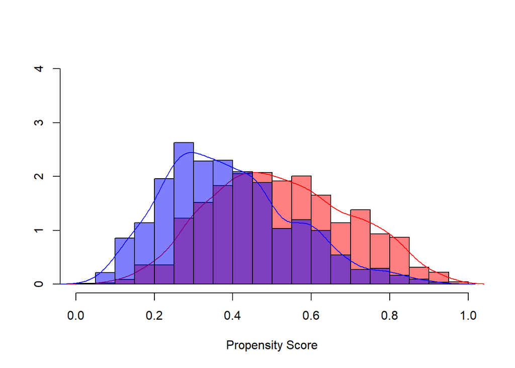

**Low dimensional data:**

```
## Processing time of propensity score estimation by Logistic Regression for low dimensional data is 0.01699281 seconds.
```

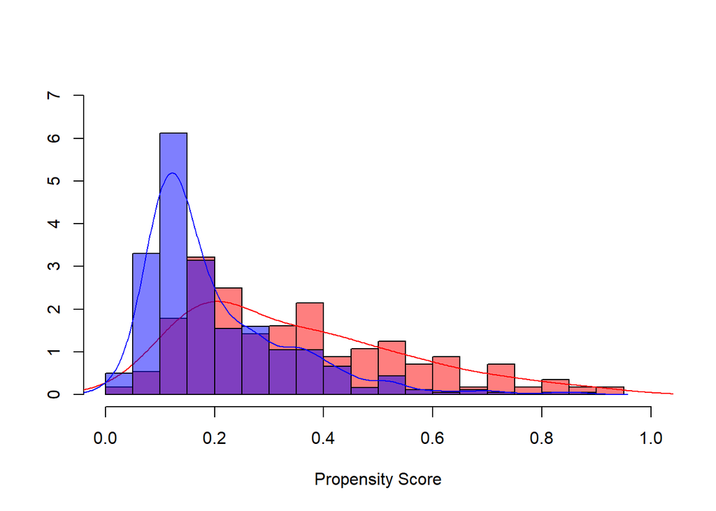

##### 1.1.2 Estimate by L1 Penalized Logistic Regression

Regularization term is introduced to decrease the model variance in the loss function $Q$ in order to avoid overfitting of logistic regression model. For both L1 and L2 Penalized Logistic Regression, we modifying the loss function with a penalty term which effectively shrinks the estimates of the coefficients.

Lasso Regression (Least Absolute Shrinkage and Selection Operator) with L1 norm penalty term, adds “absolute value of magnitude” of coefficient as penalty term to the loss function.
$$Q = -\frac{1}{n}\sum_{i=1}^{n}[y_i(\beta_0+\beta_1x_{i1}+...+\beta_px_{ip})+log(1+exp(\beta_0+\beta_1x_{i1}+...+\beta_px_{ip}))]+ \lambda\sum_{j=1}^{p}|\beta_j|$$
where $Y \in \{0,1\}$

**High Dimension Data**

```
## Processing time of propensity score estimation by L1 Penalized Logistic Regression for high dimensional data is 0.03801513 seconds.
```

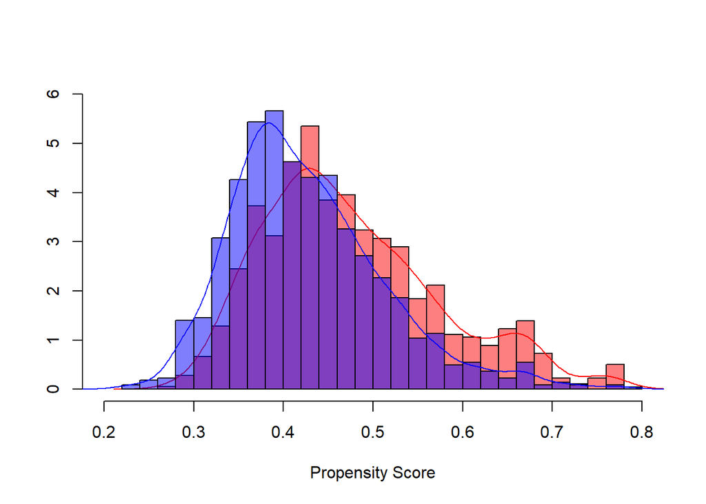

**Low Dimension Data**

```
## Processing time of propensity score estimation by L1 Penalized Logistic Regression for low dimensional data is 0.00799799 seconds.
```

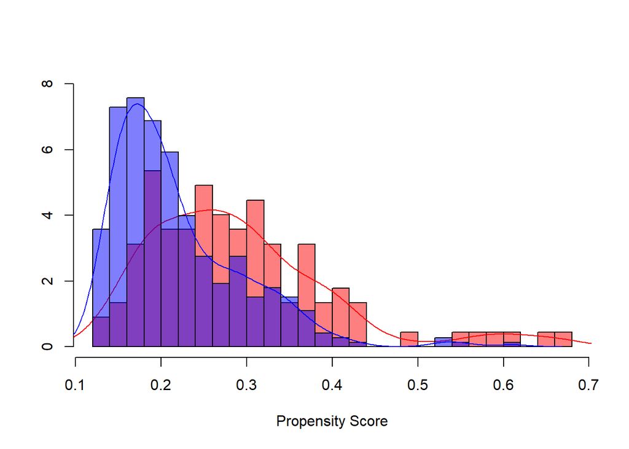

##### 1.1.3 Estimate by L2 Penalized Logistic Regression

Ridge regression with L2 norm penalty term adds “squared magnitude” of coefficient as penalty term to the loss function.
$$Q = -\frac{1}{n}\sum_{i=1}^{n}[y_i(\beta_0+\beta_1x_{i1}+...+\beta_px_{ip})+log(1+exp(\beta_0+\beta_1x_{i1}+...+\beta_px_{ip}))]+ \lambda\sum_{j=1}^{p}{\beta_j}^2$$

**High Dimension Data**

```
## Processing time of propensity score estimation by L2 Penalized Logistic Regression for high dimensional data is 0.06400299 seconds.
```

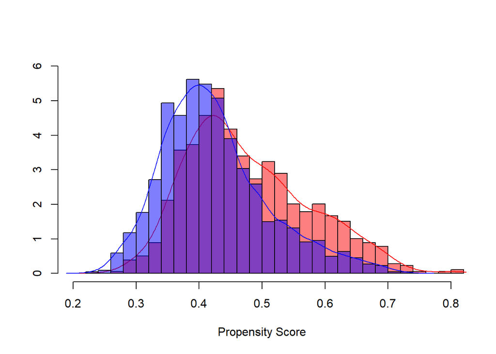

**Low Dimension Data**

```
## Processing time of propensity score estimation by L2 Penalized Logistic Regression for low dimensional data is 0.06400299 seconds.
```

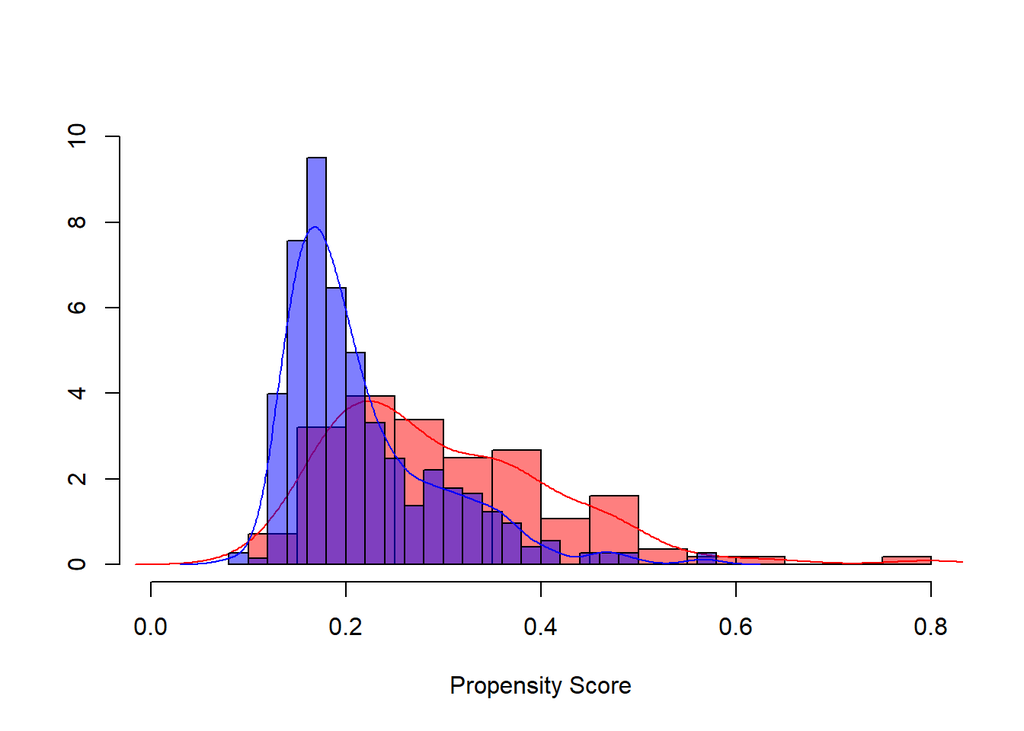

##### 1.1.4 Estimate by Regression Trees (CART)

Classification and regression trees could use decision tree model and provide probability of class membership. We first split the space into two regions, and model the response by the mean of $Y$ in each region. We choose the variable and split-point to achieve the best fit. Then one or both of these regions are split into two more regions, and this process in continued, until some stopping rule is applied. The corresponding regression model predicts $Y$ with a constant $c_m$ in region $R_m$, that is,
$$\hat{f(x)} = \sum_{m=1}^{M}c_mI\{x \in R_m\}$$

**High Dimension Data**

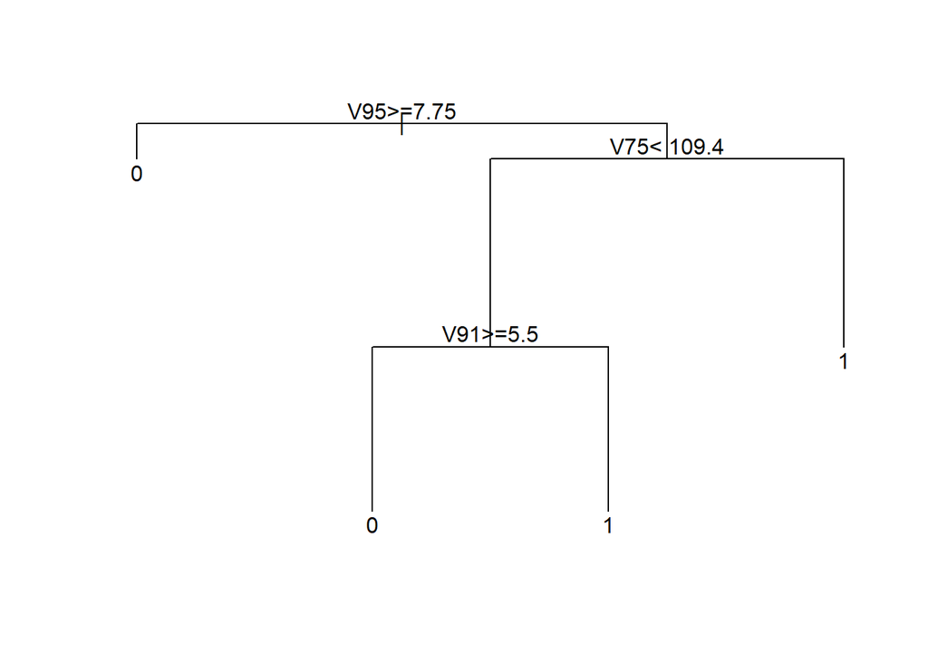

```
## Processing time of propensity score estimation by Regression Trees (CART) for high dimensional data is 1.751002 seconds.
```

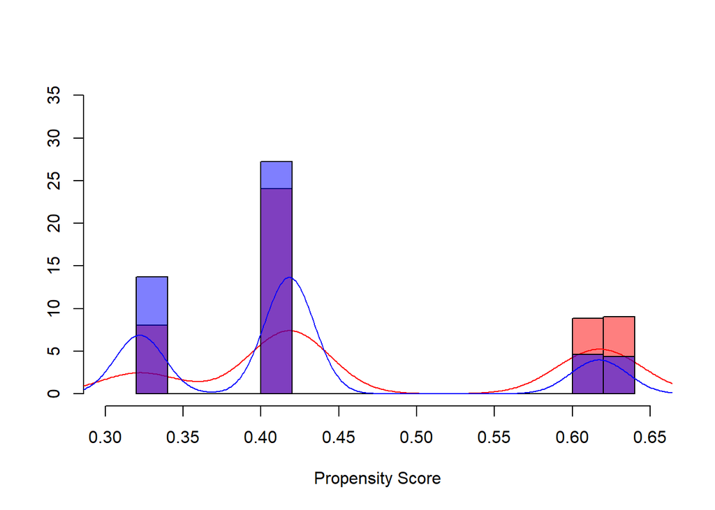

**Low Dimension Data**

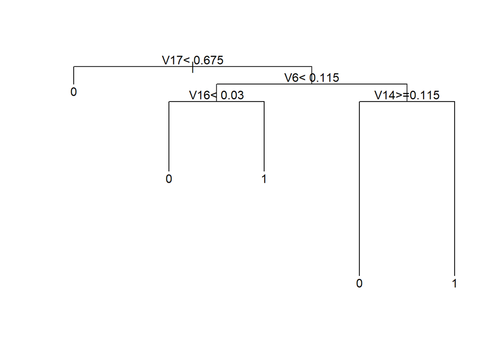

```
## Processing time of propensity score estimation by Regression Trees (CART) for low dimensional data is 0.05399203 seconds.
```

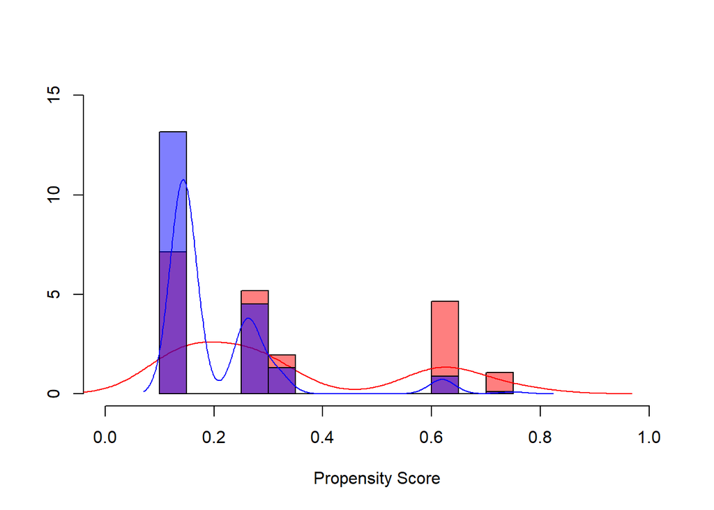

##### 1.1.5 Estimate by Boosting Stumps

We can represent the boosting stumps model as an addictive model:
$$f_M(x) = \sum_{m=1}^{M}T(x;\Theta_m)$$
where $T(x;\theta)$ is the stump, $\Theta_m$ is the parameter of the tree stump, $M$ is the number of tree stumps.

**High Dimension Data**

```
## CV: 1
## CV: 2
## CV: 3
## CV: 4
## CV: 5
```

```
## Processing time of propensity score estimation by Boosting Stumps for high dimensional data is 3.375969 seconds.
```

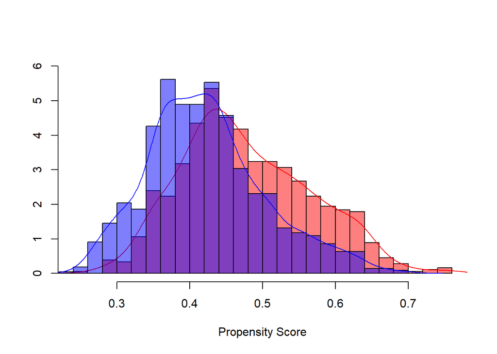

**Low Dimension Data**

```
## CV: 1
## CV: 2
## CV: 3
## CV: 4
## CV: 5
```

```
## Processing time of propensity score estimation by Boosting Stumps for low dimensional data is 0.1110091 seconds.
```

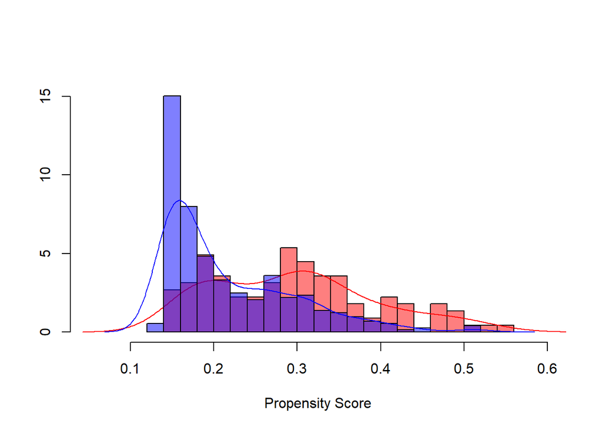

#### 1.2 Oversampling for Imbalanced Classification

Since the treatment classification (A) ratio is $1103 (0) : 897 (1) = 1.229654$ in high dimension data, and the treatment classification (A) ratio is $363 (0) : 112 (1) = 3.241071$ in low dimension data. We decided to use Synthetic Minority Oversampling Technique to generate synthetic positive instances using SMOTE algorithm only on low dimension data. After oversampling, the treatment classification (A) ratio is $363 (0) : 336 (1) = 1.080357$ in low dimension data.

##### 1.2.1 Estimate by Logistic Regression

```
## Processing time of propensity score estimation by Logistic Regression for balanced low dimensional data is 0.01499987 seconds.
```

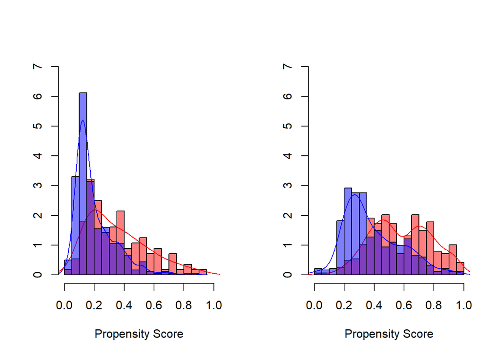

##### 1.2.2 Estimate by L1 Penalized Logistic Regression

```
## Processing time of propensity score estimation by L1 Penalized Logistic Regression for balanced low dimensional data is 0.01000309 seconds.
```

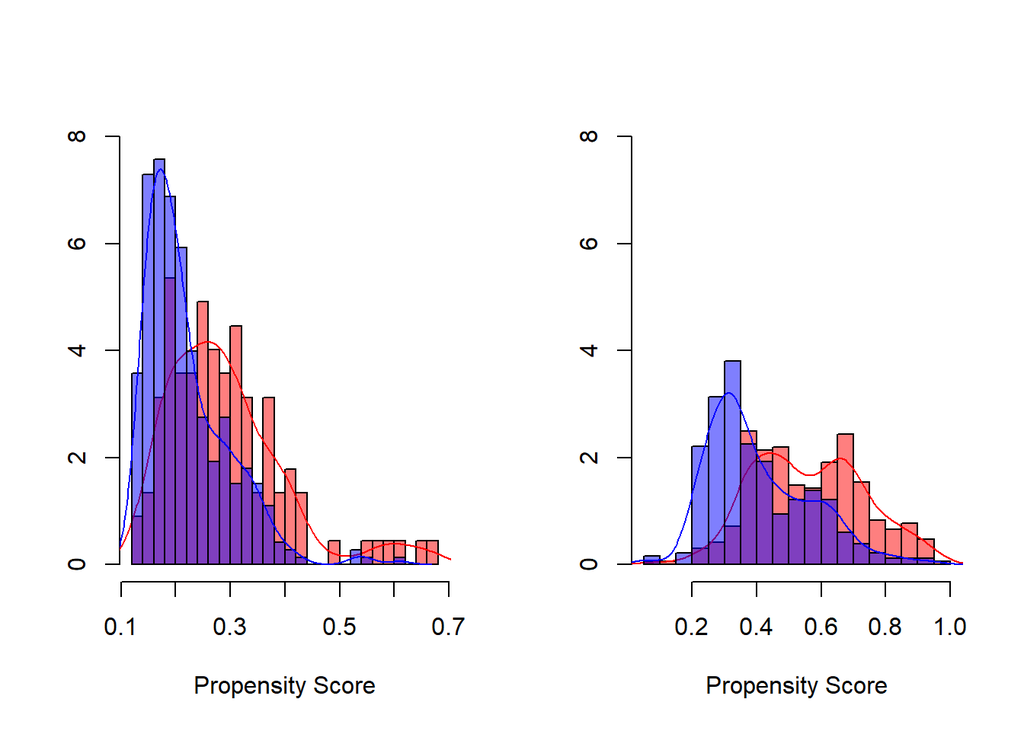

##### 1.2.3 Estimate by L2 Penalized Logistic Regression

```
## Processing time of propensity score estimation by L2 Penalized Logistic Regression for balanced low dimensional data is 0.009998083 seconds.
```

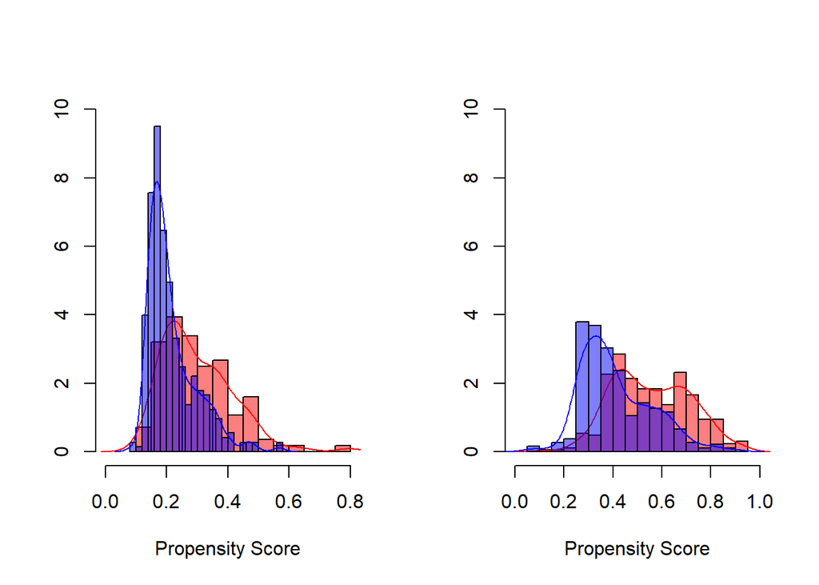

##### 1.2.4 Estimate by Regression Trees (CART)

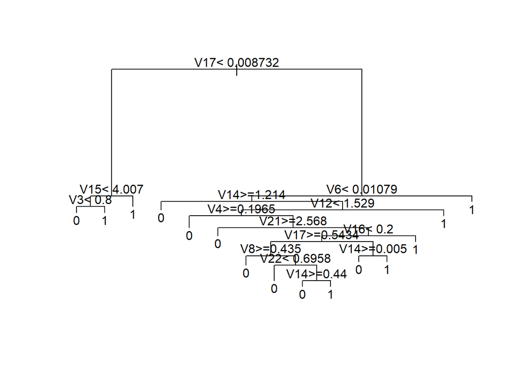

```
## Processing time of propensity score estimation by Regression Trees (CART) for balanced low dimensional data is 0.09299803 seconds.
```

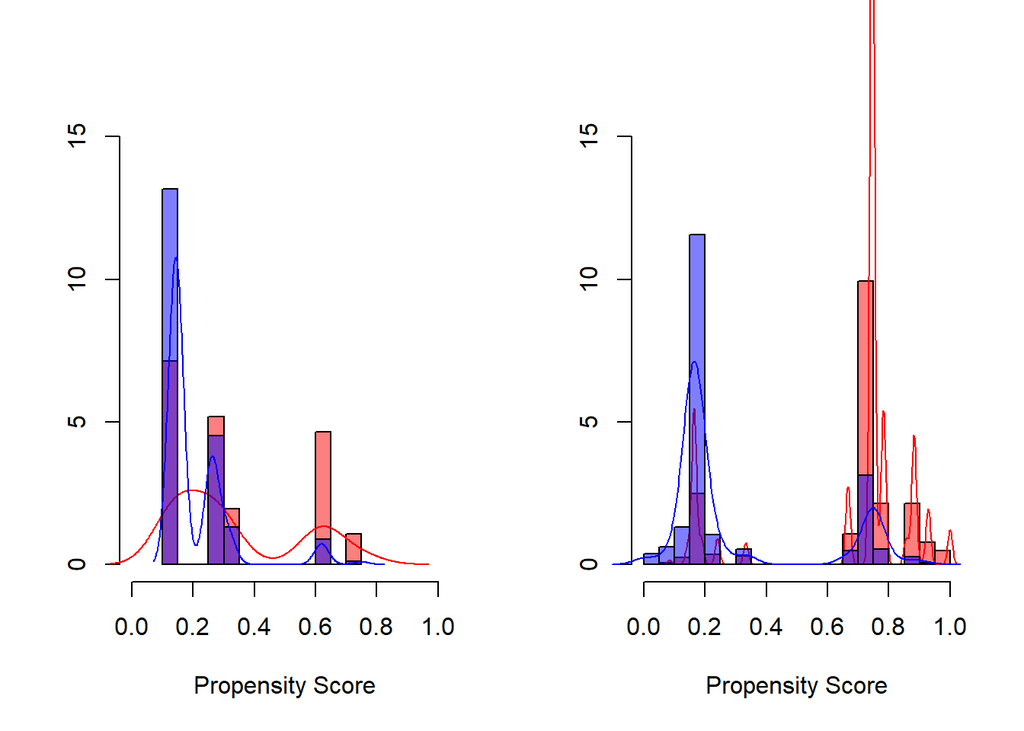

##### 1.2.5 Estimate by Boosting Stumps

```
## CV: 1
## CV: 2
## CV: 3
## CV: 4
## CV: 5
```

```
## Processing time of propensity score estimation by Boosting Stumps for balanced low dimensional data is 0.2250271 seconds.
```

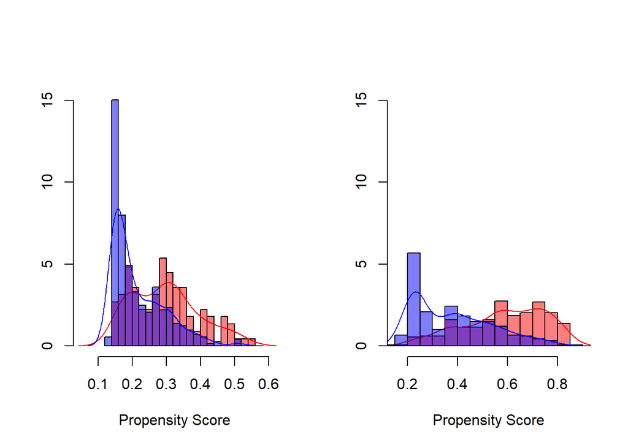

### 2. Propensity Score Matching

Full matching is a type of subclassification that forms the subclasses in an optimal way. It creates a series of matched sets where each matched set contains at least one treated individual and at least one control individual. Full matching is optimal in terms of minimizing a weighted average of the estimated distance measure between each treated subject and each control subject within each subclass. Here, we use propensity score to measure the distance.

```
##                  Logistic        L1        L2      CART        BS
## highdim         -2.985818 -2.939771 -3.268819 -3.110418 -3.542559
## lowdim           2.855779  2.971267  3.094955  9.701434  2.870900
## balanced lowdim  2.386179  2.628000  2.408261  2.532557  2.268999
```

### 3. Weighted Regression

We will use the propensity score that estimated by logistic regression in part 1.1.1 and apply weighted regression to estimate ATE. Weighted least square estimation of the regression function:
$$Y_i=\alpha_0+\tau*T_i+\alpha_1^{'}*Z_i+\alpha_2^{'}*(Z_i-\bar{Z})*T_i+\epsilon_i$$
The weight $w_i$ is:
$$w_i=\frac{T_i}{\hat{e_i}}+\frac{1-T_i}{1-\hat{e_i}}$$
where $\hat{e_i}$ is the estimated propensity score for individual i. This weighting serves to weight both the treated and control groups up to the full sample The $Z_i$ are a subset of the covariates $X_i$ with sample average $\bar{Z}$. $\tau$ is an estimate for ATE

#### 3.1 Estimate by Logistic Regression + Weighted Regression

**High dimensional data:** First, we need to find $Z_i$ which is the subset of the covariates $X_i$, we will select $Z$ by estimating linear regressions:
$$Y_i=\beta_{k0}+\beta_{k1}*T_i+\beta_{k2}*X_{ik}+\epsilon_i$$
We calculate the t-statistic for the test of the null hypothesis that the slope coefficient $\beta_{k2}$ is equal to zero in each of these regressions, and now select for $Z$ all the covariates with a t-statistic larger in absolute value than 1.96. we will only keep covariates with t-values less than 1.96 or larger than 1.96. Therefore, the following covariates do not qualify:

```
##  [1] V1         V2         V4         V5         V8         V9
##  [7] V13        V15        V18        V28        V29        V34
## [13] V36        V39        V41        V42        V43        V44
## [19] V47        V49        V50        V52        V53        V54
## [25] V55        V57        V58        V59        V97        V151
## [31] weight.ATE
## 189 Levels: Y A V1 V2 V3 V4 V5 V6 V7 V8 V9 V10 V11 V12 V13 V14 V15 V16 ... weight.ATE
```

After deleting the above variables, ATE is estimated by following result, which is around -4.135:

```
## [...]
## Coefficients:
##                  Estimate Std. Error t value Pr(>|t|)
## (Intercept)     6.876e-01  4.061e-01   1.693  0.09058 .
## A              -4.135e+00  5.817e-01  -7.109 1.72e-12 ***
## [...]
```

**Low dimensional data:** For low dimensional data, we follow the same steps, first is to find the subset:

```
## [1] V2  V4  V8  V9  V11 V14 V16 V20
## 26 Levels: Y A V1 V2 V3 V4 V5 V6 V7 V8 V9 V10 V11 V12 V13 V14 V15 V16 ... weight.ATE
```

After deleting the above variables, ATE is estimated by following result, which is around 2.788:

```
## [...]
## Coefficients:
##               Estimate Std. Error t value Pr(>|t|)
## (Intercept)   10.94462    0.14003  78.158  < 2e-16 ***
## A              2.78831    0.21032  13.257  < 2e-16 ***
## [...]
```

**Low dimensional balanced data:** For low dimensional data, we follow the same steps, first is to find the subset:

```
## [1] V4         V8         V9         V11        V14        V20        weight.ATE
## 26 Levels: Y V1 V2 V3 V4 V5 V6 V7 V8 V9 V10 V11 V12 V13 V14 V15 V16 V17 ... weight.ATE
```

[output not shown]

### Summary

#### ATE results comparison

```
##                 Logistic_FullMatching L1_FullMatching L2_FullMatching
## highdim                     -2.985818       -2.939771       -3.268819
## lowdim                       2.855779        2.971267        3.094955
## balanced lowdim              2.386179        2.628000        2.408261
##                 CART_FullMatching BS_FullMatching Logistic_WeightedReg True_ATE
## highdim                 -3.110418       -3.542559             -4.13500     -3.0
## lowdim                   9.701434        2.870900              2.78831      2.5
## balanced lowdim          2.532557        2.268999              2.84753       NA
```

#### Propensity score estimation time

The following table shows each method’s time of estimating propensity scores. We could see that L1 runs fastest, which followed closely by L2. The reason might be L1 and L2 penalized strictly on dataset, therefore, they will only choose covariates that most related with.

```
##                   Logistic         L1         L2       CART       BS
## highdim         0.39100190 0.03896785 0.05304599 1.48576000 3.217024
## lowdim          0.03999996 0.01000094 0.05304599 0.04700000 0.073946
## balanced lowdim 0.01700902 0.01003218 0.01000118 0.08700299 0.229990
```

#### ATE estimation time

The following table shows each method’s time of estimating ATE. We could see that Weighted Regression performs much better than FullMatching. The reason might because the package MatchIt will be slower while processing large dataset. In the future, we could try different packages to see if the running time can be improved.

```
##                 Logistic_FullMatching L1_FullMatching L2_FullMatching
## highdim                     2.8449991       1.3979990        1.468000
## lowdim                      0.7870090       0.1590080        0.128001
## balanced lowdim             0.2279952       0.2280049        0.222002
##                 CART_FullMatching BS_FullMatching Logistic_WeightedReg
## highdim                 1.7649920       1.4010241                 0.27
## lowdim                  0.1540310       0.1390040                 0.01
## balanced lowdim         0.2289681       0.2199762                 0.02
```

### References

https://github.com/TZstatsADS/ADS_Teaching/blob/master/Tutorials/wk10-overview-casual-inference-methods.pdf